# Germany Economic Analysis

Group Germany

2024-12-03

## SECTION 1

In the first section, we make an analysis of the spatial distribution of GDP and Research and Development (R&D) expenditures across Germany’s regions from the years 2017 to 2019. The main goal here is to see the pattern of how the geographical distribution of these two variables correlates. The hypothesis here is whether both variables have a positive impact on each other, while having also a strong correlation. Thus by conducting this analysis, we can draw conclusions regarding the relationship between these two variables, in our case for Germany.

**Data Preparation:**

Data preparation is one of the most crucial steps. After cleaning, tidying, and transforming the data, the final dataset used for analysis, referred to as deu, has the following relevant variables:

- **GDP:** Regional GDP in millions of euros for each region from 2017 to 2019.
- **R&D:** Regional R&D expenditures in millions for each region.
- **Region:** The name of the federal state or region in Germany (total of 16 regions).
- **Year:** The period (2017, 2018, 2019).
- **geometry:** Spatial data for each region of Germany, containing values in multi polygons.

We also used the sf package to convert the dataset into a spatial object, deu, to improve mapping so it could be more precise.

## PRE-PROCESS DATA

```r
############################ First stage

#We start the task by importing first dataset in xlsx format of one of key variables in our
#research, which is GDP by region in mil EU.

gdp <- read_xlsx("gdp.xlsx", sheet = "Sheet 1", skip=7)
```

```r
#remove unnecessary columns
gdp <- gdp %>%
  select(-starts_with("..."))

#remove NA values
gdp <- na.omit(gdp)

#renaming for appropriate name
gdp <- rename(gdp, Region = TIME)

#selecting relevant years
gdp <- select(gdp,'Region','2017','2018','2019')

#Tidying the data by making it longer and more organized.
#Year should be considered as value
gdp <- gdp %>%
  pivot_longer(
    cols = "2017":"2019",
    names_to = "Year",
    values_to = "GDP_mln")

#creating a list of region names corresponding for each subregion
region_to_state <- list(
  "Baden-Württemberg_" = c("Stuttgart", "Karlsruhe", "Freiburg", "Tübingen"),
  "Bayern_" = c("Oberbayern", "Niederbayern", "Oberpfalz", "Oberfranken", "Mittelfranken", "Unterfranken", "Schwaben"),
  "Berlin_" = "Berlin",
  "Brandenburg_" = "Brandenburg",
  "Bremen_" = "Bremen",
  "Hamburg_" = "Hamburg",
  "Hessen_" = c("Darmstadt", "Gießen", "Kassel"),
  "Mecklenburg-Vorpommern_"="Mecklenburg-Vorpommern",
  "Niedersachsen_" = c("Braunschweig", "Hannover", "Lüneburg", "Weser-Ems"),
  "Nordrhein-Westfalen_" = c("Köln", "Münster", "Detmold", "Arnsberg"),
  "Rheinland-Pfalz_" = c("Rheinhessen-Pfalz","Koblenz","Trier"),
  "Saarland_" = "Saarland",
  "Sachsen_" = c("Dresden", "Chemnitz", "Leipzig"),
  "Sachsen-Anhalt_" = "Sachsen-Anhalt",
  "Schleswig-Holstein_" = "Schleswig-Holstein",
  "Thüringen_" = "Thüringen")

#unlisting the previous list
region_to_state_vec <- unlist(region_to_state)

#creating new column of regions matching each subregion
gdp$FederalState <- names(region_to_state_vec)[match(gdp$Region, region_to_state_vec)]

#separating columns values to remove unecessary signs
gdp <- gdp %>%
  separate(FederalState, into = c("FederalState", "number"), sep = "_")

#removing unecessary columns and renaming federal states to regions for comfort use
gdp <- gdp %>%
  select(-"number", -"Region") %>%
  rename(Region = FederalState)

#grouping region and year variable to sum up GDP values for each unique region
gdp <- gdp %>%
  group_by(Region, Year) %>%
  summarize(GDP_mln = sum(GDP_mln))
```

```r
############################ Second stage

#Now we import the second variable, which is regarding Research and Development
#expenditures in mil EU
rd <- read_xlsx("R&D expenditure and staff.xlsx")

#remove NA values, extra columns, and filter for EUR mn
rd <- na.omit(rd)
rd <- filter(rd, Unit=='EUR mn')
rd <- select(rd, -c("Unit","Type"))

#transforming columns of regions to a longer format
rd <- rd %>%
  pivot_longer(
    cols = "Baden-Württemberg":"Thüringen",
    names_to = "Region",
    values_to = "R&D expenditure"
  )

#transforming unique sector names to columns to make dataset wider
rd <- pivot_wider(rd,names_from='Sector',
                  values_from='R&D expenditure')

#to show needed variables
rd <- select(rd, Year, Region, Total)

#Merging two variables' datasets into one
gdp_rd <- merge(gdp, rd , by=c('Region', 'Year'))

############################ Third stage

#Now we import the shapefile containing Germany map data
deu <- read_sf('gadm41_DEU_2.shp')

#renaming for appropriate name
deu <- rename(deu, Region=NAME_1)

#Merging every dataset into one
deu <- merge(deu, gdp_rd, by='Region')

#renaming for appropriate name
deu <- rename(deu, "R&D_mln"=Total)

#to show needed variables
deu <- select(deu, Region, Year, GDP_mln, "R&D_mln", geometry)
deu_all<-select(deu, Region, Year, GDP_mln, "R&D_mln", geometry)

#convert to sf format for more precision
section_1_data <- st_as_sf(deu)
```

## VIZUALIZATION OF SECTION 1

**Visualization of Regional Distributions:**

To properly understand the spatial distribution, we visualized the distribution of GDP and R&D spendings across Germany using choropleth maps. The first map represents **Regional GDP**, and the second one shows **R&D expenditures**.

- **GDP Map:** The choropleth map for GDP reveals regions with higher GDP values, typically represented by darker shades, in which dark-blue for the highest and light-yellow for the lowest values. The southern regions, such as **Bavaria** and **Baden-Württemberg**, and also some parts of western Germany stand out with darker shades, indicating higher economic development. In comparison, the eastern regions show lighter shades, representing lower GDP values.
- **R&D Map:** The distribution of R&D expenditures follows a similar pattern, with dark-red for the highest and light-yellow for the lowest numbers of expenditure.

```r
plot1 <- tm_shape(section_1_data) +
  tm_polygons(col = "GDP_mln",
              style = "pretty",
              palette = brewer.pal(9, "YlGnBu"),
              border.col = "black",
              lwd = 0.2) +
  tm_facets(along = "Year", free.coords = FALSE) +
  tm_layout(
    main.title.size = 2,
    main.title.position = "center",
    main.title.fontface = "bold",
    legend.width = 4,
    legend.title.size = 1,
    legend.text.size = 1,
    legend.outside = TRUE,
    legend.position = c("left","bottom"),
    bg.color = "#E0FFFF",
    frame = FALSE) +
  tm_compass(
    type = "8star",
    position = c("left", "bottom"),
    size = 2
  )


#Plotting the second variable
plot2 <- tm_shape(section_1_data) +
  tm_polygons(col = "R&D_mln",
              style = "pretty",
              palette = brewer.pal(9, "YlOrRd"),
              border.col = "black",
              lwd = 0.2) +
  tm_facets(along = "Year", free.coords = FALSE) +
  tm_layout(
    main.title.size = 2,
    main.title.position = "center",
    main.title.fontface = "bold",
    legend.width = 4,
    legend.title.size = 1,
    legend.text.size = 1,
    legend.outside = TRUE,
    legend.position = c("left","bottom"),
    bg.color = "#FFEFDB",
    frame = FALSE) +
  tm_compass(
    type = "8star",
    position = c("left", "bottom"),
    size = 2
  )
```

```r
#Animating maps of two variables
tmap_animation(plot1, filename = "gdp.gif", delay = 90)
```

```
## Creating frames
```

```
##
## Creating animation
## Animation saved to C:\Users\User\OneDrive\Рабочий стол\FINAL\gdp.gif
```

```r
tmap_animation(plot2, filename = "rd.gif", delay = 90)
```

```
## Creating frames
```

```
##
## Creating animation
## Animation saved to C:\Users\User\OneDrive\Рабочий стол\FINAL\rd.gif
```

## GDP per region

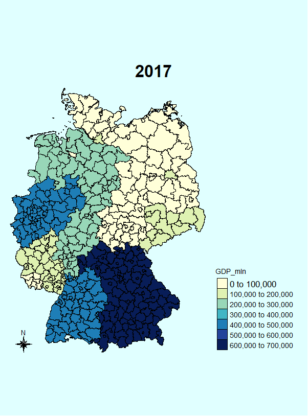

## R&D expenditures

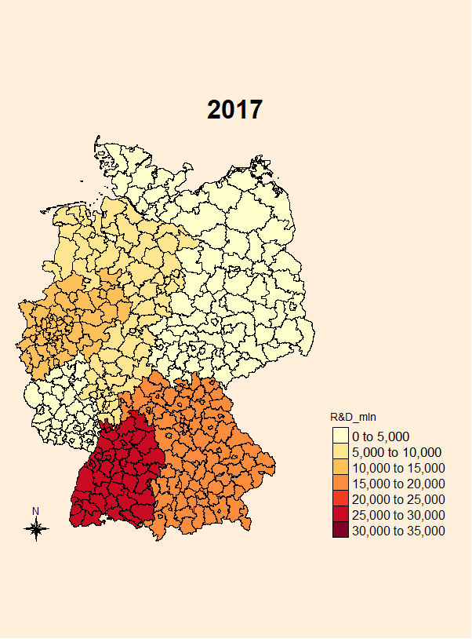

**Interpretation of Patterns:**

The pattern of the darker and lighter regions across both maps after plotting them suggests a relatively strong correlation between **R&D investment** and **GDP performance** across German regions. Specifically:

- **Southern Regions:** **Bavaria (Bayern)** and **Baden-Württemberg**, with their well-developed industrial progress and infrastructure, show high values for both GDP and R&D consistently for 3 years.
- **Eastern Regions:** The regions in eastern Germany surrounding Berlin, have the opposite case with lower R&D investments and GDP values. This pattern may suggest that these regions faced some challenges in the economy from 2017 to 2019, which can be possibly explained by historical factors in that region.
- **Western Regions:** These regions in western Germany demonstrate quite high indicators for variables’ distributions while being approximately lower than southern Germany and higher than eastern Germany.

## CONCLUSION OF SECTION 1

Overall, the maps showcase very close geographical patterns between **GDP** and **R&D expenditures**, with higher values for both variables concentrated in the southern and western regions of Germany. The visual patterns shown by choropleth maps indicate that higher R&D investments correlate with better economic output, in our case measured in GDP. However, the lighter shades in the eastern regions show the opposite situation with lower values. Nevertheless, conducting a choropleth map analysis suggests that these results generally support our proposed hypothesis, within our case. These observations support the thought that investment growth in research and development, specifically in light-shaded regions of Germany, is required to make the whole of Germany having relatively the same colors.

**References**

[1] Ozturk, F. O. (2022). The Interaction Among R&D Expenses and Economic Growth Evidence From EU Transition Economies.https://www.igi-global.com/gateway/chapter/301884

[2] Moustapha, A., Yu, Q. (2020). Innovation Effect Through Research and Development on Economic Growth in 35 OECD Countries.https://typeset.io/pdf/innovation-effect-through-research-and-development-on-3602rf67uh.pdf

[3] D. Gaidhani, N. Nair, S. Jadhav, S. Rastogi and V. Mrudula Bhimavarapu (2022), Impact of Research and Development on The Gdp Growth Rate of Nations: Evidence Using Panel Data.https://ieeexplore.ieee.org/document/9786420

[4] Islamoglu, E. (2017). Causality Relationship of Research & Development Investment Expenditures and Gross Domestic Product: Comparison of Turkey and Selected Oecd Countries.https://www.researchgate.net/publication/340875546_Causality_Relationship_of_Research_Development_Investment_Expenditures_and_Gross_Domestic_Product_Comparison_of_Turkey_and_Selected_Oecd_Countries

[5] Meo, SA., Al Masri, AA., Usmani, AM., Memon, AN., Zaidi, SZ. (2013), Correction: Impact of GDP, Spending on R&D, Number of Universities and Scientific Journals on Research Publications among Asian Countries.https://journals.plos.org/plosone/article?id=10.1371/journal.pone.0066449

## SECTION 2

Building upon the analysis in Section 1, this section introduces the **student rate of higher education** as an additional variable to assess the role of education in economic development. Following the work of Oketch et al. (2014), education is recognized as a significant driver of economic growth through the enhancement of human capital. Grant (2017) considered that the human element consists of three most important parts and education is one of them. This section also looks for the correlation between education and R&D expenditures, testing the hypothesis that regions with stronger R&D investment and better economic development have more students. However, the results show a more complex reality where this hypothesis does not consistently hold.

## DATA PREPARATION

We found data from various sources and prepared it for analysis. The final dataset, all_data, includes the following variables: **GDP:** Regional GDP in millions of euros (2017–2019). **Students:** Number of students in each region (2017–2019). **R&D:** Regional R&D expenditures in millions (2017–2019). **Region:** The name of Germany’s 16 federal states. **geometry:** Geometric data in polygon format for spatial visualizations.

R packages such as sf, dplyr, and tmap were used for data processing, visualization, and spatial analysis. The dataset was converted into an sf object to enable precise mapping and visual analysis.

## PRE-PROCESS GDP DATA

```r
#same for gdp and also omit NAs
gdp<-select(gdp,TIME,starts_with('20'))
gdp<-rename(gdp,Region=TIME)
gdp<-na.omit(gdp)
gdp<-select(gdp,'Region','2017','2018','2019')


########################################################
#create a list of regions and then assign the necessary subregions to them
region_to_state <- list(
  "Baden-Württemberg_" = c("Stuttgart", "Karlsruhe", "Freiburg", "Tübingen"),
  "Bayern_" = c("Oberbayern", "Niederbayern", "Oberpfalz", "Oberfranken", "Mittelfranken", "Unterfranken", "Schwaben"),
  "Berlin_" = "Berlin",
  "Brandenburg_" = "Brandenburg",
  "Bremen_" = "Bremen",
  "Hamburg_" = "Hamburg",
  "Hessen_" = c("Darmstadt", "Gießen", "Kassel"),
  "Mecklenburg-Vorpommern_"="Mecklenburg-Vorpommern",
  "Niedersachsen_" = c("Braunschweig", "Hannover", "Lüneburg", "Weser-Ems"),
  "Nordrhein-Westfalen_" = c("Köln", "Münster", "Detmold", "Arnsberg"),
  "Rheinland-Pfalz_" = c("Rheinhessen-Pfalz","Koblenz","Trier"),
  "Saarland_" = "Saarland",
  "Sachsen_" = c("Dresden", "Chemnitz", "Leipzig"),
  "Sachsen-Anhalt_" = "Sachsen-Anhalt",
  "Schleswig-Holstein_" = "Schleswig-Holstein",
  "Thüringen_" = "Thüringen")
#unlist previous list to create vector
region_to_state_vec <- unlist(region_to_state)
#creating new columns for region(Federal_Sates) using previous vector and match them with regions
gdp$Federal_State <- names(region_to_state_vec)[match(gdp$Region, region_to_state_vec)]

#cleaning Federal States column
gdp<-gdp%>%
  separate(Federal_State, into = c("Federal_State", "number"), sep = "_")
#remove unnecessary column
gdp$number=NULL

########################################################
# change GDP data to long format, group, and summarize
gdp<-pivot_longer(gdp,cols=starts_with('20'),
                            values_to='Value',
                            names_to='Year')

gdp<-gdp%>%
  group_by(Federal_State,Year)%>%
  summarize(TotalGDP=sum(Value,na.rm=TRUE))
#return to wide format
gdp<-pivot_wider(gdp,names_from='Year',
                            values_from='TotalGDP')
#rename
gdp<-rename(gdp,Region=Federal_State)
```

## PRE-PROCESS EDUCATION DATA

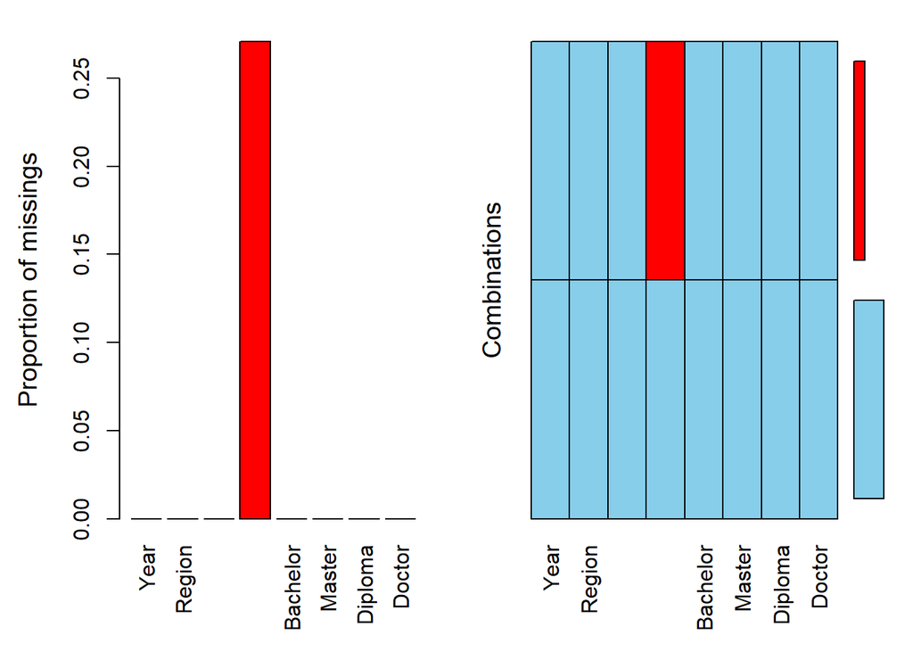

```r
#######################################################
#filtering education variable
education<-filter(education,Sex=='Total')
education$Sex<-NULL
education$Total<-NULL
education<-rename(education,'Trade_and_technical_school_certificate'='Trade and technical school certificate')
education<-rename(education,'Specialised_and_engineering_school_certificate_GDR'='Specialised and engineering school certific. (GDR)')
education<-rename(education,"Doctor"="Doctor's degree")
education$Specialised_and_engineering_school_certificate_GDR<-as.numeric(education$Specialised_and_engineering_school_certificate_GDR)
education$Year<-as.numeric(education$Year)

#check at missingness
aggr(education)
```

```r
#impute data where were NA
imp<-mice(education,method='pmm',maxit=10,m=1)
education<-complete(imp,action='long',include=FALSE)

education$.imp<-NULL
education$.id<-NULL
#sum u Student rate per 10,000 people and select
education<-education%>%
  mutate(Total=Trade_and_technical_school_certificate+Specialised_and_engineering_school_certificate_GDR+Bachelor+Master+Diploma+Doctor)
education<-education%>%
  select(Year,Region,Total)
#change format
education<-education%>%
  pivot_wider(names_from='Year',
              values_from='Total')
```

## PRE-PROCESS R&D DATA

```r
#########

RD<-na.omit(RD)
RD<-filter(RD,Unit=='EUR mn')
RD$Unit<-NULL
RD$Type<-NULL

RD<-pivot_longer(RD, cols=('Baden-Württemberg':'Thüringen'),
                 values_to='Value',
                 names_to='Region')

RD<-pivot_wider(RD,
                names_from='Sector',
                values_from='Value')

RD$Gov<-RD$`Government, private non-profit institutions`
RD$`Government, private non-profit institutions`<-NULL
RD<-select(RD,Year,Region,Total)

RD<-pivot_wider(RD,
                names_from='Year',
                values_from='Total')
```

## MERGING ALL DATA

```r
#merge data of all variables
all_data<-merge(gdp, education, by='Region')
all_data<-merge(all_data,RD, by="Region")
all_data<-merge(all_data, germany, by='Region')
#rename for comfort use
all_data<-all_data%>%
  rename(
    GDP_2017 = `2017.x`,
    GDP_2018 = `2018.x`,
    GDP_2019 = `2019.x`,
    Students_2017 = `2017.y`,
    Students_2018 = `2018.y`,
    Students_2019 = `2019.y`,
    RD_2017=`2017`,
    RD_2018=`2018`,
    RD_2019=`2019`)

#####
#change to spatial data frame for mapping
all_data<-st_as_sf(all_data)
tmap_mode('plot')
```

```
## tmap mode set to plotting
```

```r
#adding new dataset for population
population<- read_excel("demo_r_d2jan$defaultview_page_spreadsheet.xlsx", sheet='Sheet 1', skip=9)
```

```r
population<- select(population, -starts_with('...'))
population<-na.omit(population)
population<-select(population, 2:5)
population<-rename(population, Region=`TIME...2`) # Create maps for comparison rd vs students within years 2017, 2018, and 2019

all_data<- merge(all_data,population, by='Region')

all_data <- all_data%>%
  rename(Pop_2017=`2017`,
         Pop_2018=`2018`,
         Pop_2019=`2019`)
all_data<-all_data%>%
  mutate(Student_Rate_2017=(Students_2017*1000/Pop_2017)*100,
         Student_Rate_2018=(Students_2018*1000/Pop_2017)*100,
         Student_Rate_2019=(Students_2019*1000/Pop_2019)*100)
```

## VIZUALIZATION OF SECTION 2

The main goal of this section is to analyze the relationship between **GDP, R&D expenditures, and education** across Germany’s regions. The map from the first section is enhanced by adding bubbles that represent the number of students in higher education institutions. Six maps are created to show these relationships over the course of three years. First three maps show relationships between Regional GDP and Student Rate, while the other three maps represent correlation between R&D expenditure and Student Rate.

```r
# Create maps for comparison rd vs students within years 2017, 2018, and 2019


rd_stud_2017<-tm_shape(all_data)+
  tm_polygons(col='RD_2017', palette='YlOrRd', title='R&D expenditure(EUR mln)')+
  tm_bubbles(size = "Student_Rate_2017", col='#d46ec9',
             scale = c(1.5,2,3,4),
             alpha=0.7,
             title.size='Student rate per 10,000 people',
             border.col = "black",
             border.lwd = 0.8,
             legend.size.show = TRUE,
             border.alpha = 1)+
  tm_layout(legend.title.size = 1.5,
            legend.text.size = 1,
            legend.outside = TRUE,
            main.title ="R&D vs Students(2017)",
            bg.color = '#FFEFDB')

rd_stud_2018<-tm_shape(all_data)+
  tm_polygons(col='RD_2018', palette='YlOrRd', title='R&D expenditure(EUR mln)')+
  tm_bubbles(size = "Student_Rate_2018", col='#d46ec9',
             scale = c(1.5,2,3,4),
             alpha=0.7,
             title.size='Student rate per 10,000 people',
             border.col = "black",
             border.lwd = 0.8,
             legend.size.show = TRUE,
             border.alpha = 1)+
  tm_layout(legend.title.size = 1.5,
            legend.text.size = 1,
            legend.outside = TRUE,
            main.title ="R&D vs Students(2018)",
            bg.color = '#FFEFDB')

rd_stud_2019<-tm_shape(all_data)+
  tm_polygons(col='RD_2019', palette='YlOrRd', title='R&D expenditure(EUR mln)')+
  tm_bubbles(size = "Student_Rate_2019", col='#d46ec9',
             scale = c(1.5,2,3,4),
             alpha=0.7,
             title.size='Student rate per 10,000 people',
             border.col = "black",
             border.lwd = 0.8,
             legend.size.show = TRUE,
             border.alpha = 1)+
  tm_layout(legend.title.size = 1.5,
            legend.text.size = 1,
            legend.outside = TRUE,
            main.title ="R&D vs Students(2019)",
            bg.color = '#FFEFDB')

## Create maps for comparison gdp vs students within years 2017, 2018, and 2019

gdp_stud_2017<-tm_shape(all_data)+
  tm_polygons(col='GDP_2017', palette='YlGnBu', title='Regional GDP(EUR mln)')+
  tm_bubbles(size = "Student_Rate_2017", col='#d46ec9',
             scale = c(1.5,2,3,4),
             alpha=0.7,
             title.size='Student rate per 10,000 people',
             border.col = "black",
             border.lwd = 0.8,
             legend.size.show = TRUE,
             border.alpha = 1)+
  tm_layout(legend.title.size = 1.5,
            legend.text.size = 1,
            legend.outside = TRUE,
            main.title ="GDP vs Students(2017)",
            bg.color = '#E0FFFF')

gdp_stud_2018<-tm_shape(all_data)+
  tm_polygons(col='GDP_2018', palette='YlGnBu', title='Regional GDP(EUR mln)')+
  tm_bubbles(size = "Student_Rate_2018", col='#d46ec9',
             scale = c(1.5,2,3,4),
             alpha=0.7,
             title.size='Student rate per 10,000 people',
             border.col = "black",
             border.lwd = 0.8,
             legend.size.show = TRUE,
             border.alpha = 1)+
  tm_layout(legend.title.size = 1.5,
            legend.text.size = 1,
            legend.outside = TRUE,
            main.title ="GDP vs Students(2018)",
            bg.color = '#E0FFFF')


gdp_stud_2019 <- tm_shape(all_data) +
  tm_polygons(col = 'GDP_2019', palette = 'YlGnBu', title = 'Regional GDP(EUR mln)') +
  tm_bubbles(size = "Student_Rate_2019", col = '#d46ec9',
             scale = c(1.5,2,3,4),
             alpha = 0.7,
             title.size = 'Student rate per 10,000 people',
             border.col = "black",
             border.lwd = 0.8,
             legend.size.show = TRUE,
             border.alpha = 1) +
  tm_layout(legend.title.size = 1.5,
            legend.text.size = 1,
            legend.outside = TRUE,
            main.title = "GDP vs Student(2019)",
            bg.color = '#E0FFFF')
```

## RESULTS OF VIZUALIZATION 2.1

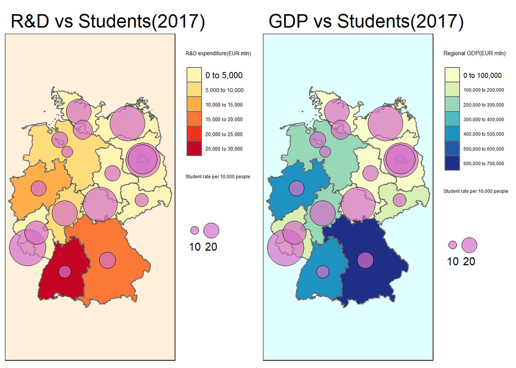

```r
#arrange maps to show comparison

tmap_arrange(rd_stud_2017, gdp_stud_2017, ncol=2)
```

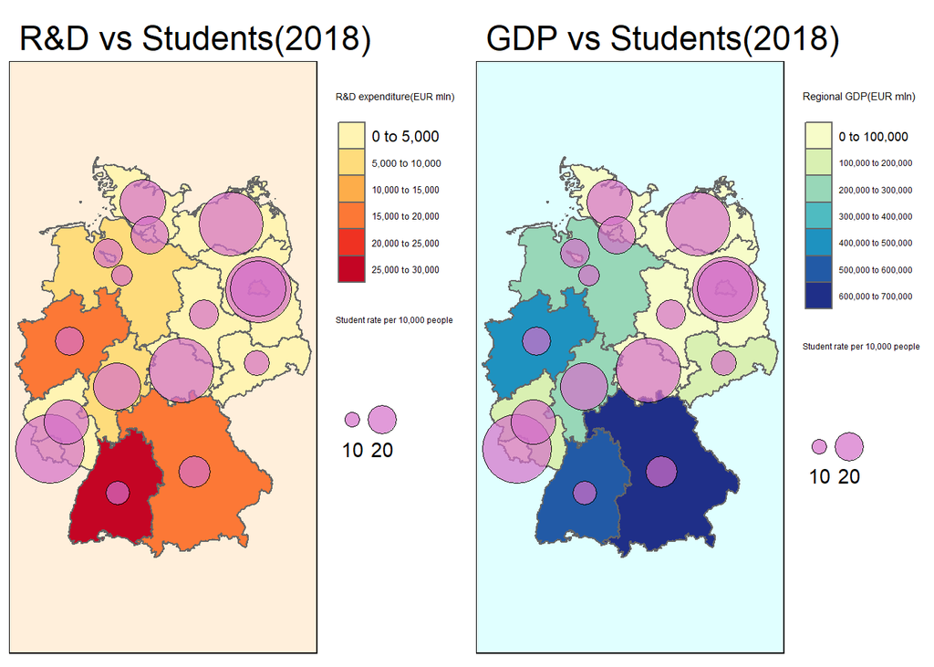

```r
tmap_arrange(rd_stud_2018, gdp_stud_2018, ncol=2)
```

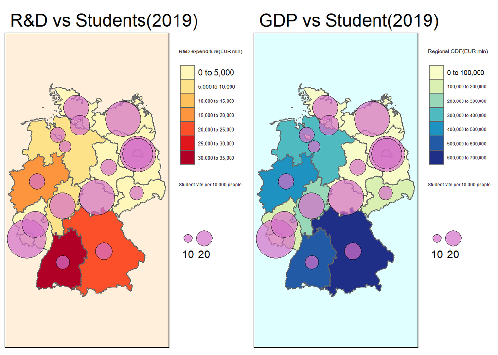

```r
tmap_arrange(rd_stud_2019, gdp_stud_2019, ncol=2)
```

Interpreting regions like **Bavaria and Baden-Württemberg** in southern Germany display higher GDP, highlighted with darker colors, while eastern regions such as **Saxony and Brandenburg** show lighter shades, indicating lower economic output, the distribution of R&D expenditures is very similar to GDP patterns, with strong investments in southern regions and lower values in the east. Also, student rate were **unexpectedly small** in more developed regions with high investment in innovation, such as North Rhine-Westphalia, Bavaria and Baden-Württemberg it shows by smaller size of bubbles. The findings suggest that student percentages and innovation are not necessarily higher in wealthier regions. Developed regions may have lower percentages of students due to large populations and diversified economies. Less developed regions exhibit higher percentages as education serves as a key lever for economic development. Faggian et al. (2007) considered that students from economically weaker regions often migrate to better-developed areas for higher education. The socio-economic characteristics of regions affect the capacity to transform R&D investments into human capital and innovation (Bilbao‐Osorio, 2004). Less developed regions often emphasize the expansion of higher education as a tool for economic growth because other factors are limited. (Ozturk, 2008). Therefore, while education is clearly an important factor in a country’s development, it will not singlehandedly lead to significant economic growth (Chen, E., 2014)

## RESULTS OF VIZUALIZATION 2.2

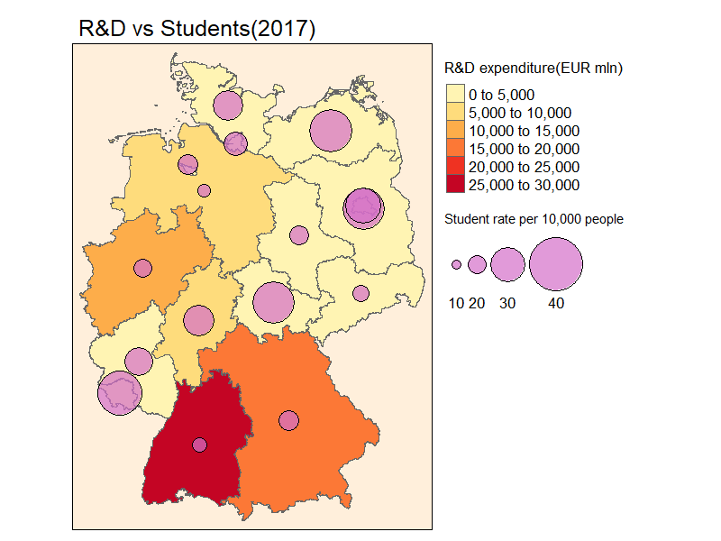

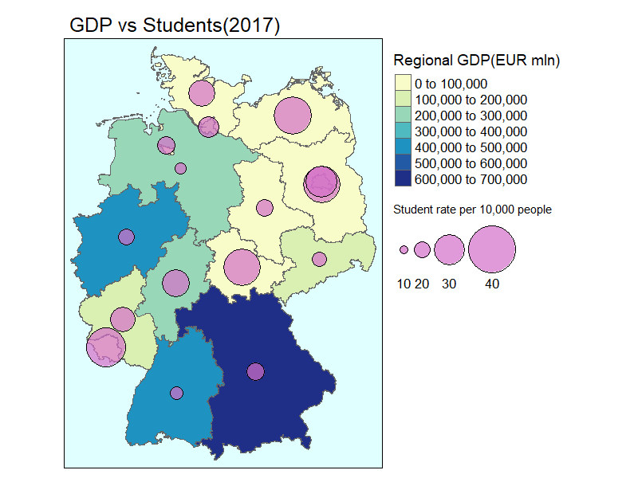

## CONCLUSION OF SECTION 2

Our hypothesis that regions with higher GDP and innovation would have more students was **not fully supported by the results.** While southern regions with higher economic output and innovation investments do exhibit larger economies, they also have a lower percentage of students. This suggests that other factors, such as population size and economic structure, may influence these patterns. The spatial distribution of GDP, R&D and education shows regional inequalities in Germany. Also we find out that southern regions consistently outperform others, while the eastern regions lag behind.

**References:**

[1] Ozturk, I. (2008). The role of education in economic development: a theoretical perspective. Available at SSRN 1137541. https://papers.ssrn.com/sol3/papers.cfm?abstract_id=1137541

[2] Grant, C. (2017). The contribution of education to economic growth. K4D Helpdesk Report. Brighton, UK: Institute of Development Studies, 25. https://www.academia.edu/90176425/The_contribution_of_education_to_economic_growth

[3] Bilbao‐Osorio, B., & Rodríguez‐Pose, A. (2004). From R&D to innovation and economic growth in the EU. Growth and Change, 35(4), 434-455.https://onlinelibrary.wiley.com/doi/abs/10.1111/j.1468-2257.2004.00256.x?casa_token=a5YRTSDXFGEAAAAA:7t_dn0IzqY83zdpKyr16jzdAmwNgbhRqrIKTLATCHZlMBPFLQX_AqzGM5ENQ8FPAU7RflLktG4SbE7nu2A

[4] Chen, E. (2014). The Impact of Education on Economic Growth (Doctoral dissertation, Stern School of Business New York).https://www.stern.nyu.edu/sites/default/files/assets/documents/Emil%20Chen_Thesis_Honors%202014.pdf

[5] Oketch, M., McCowan, T., & Schendel, R. (2014). The impact of tertiary education on development: A rigorous literature review.https://discovery.ucl.ac.uk/id/eprint/10068500/

[6] Faggian, A., McCann, P., & Sheppard, S. (2007). Human capital, higher education and graduate migration: an analysis of Scottish and Welsh students. Urban Studies, 44(13), 2511-2528. https://www.jstor.org/stable/pdf/43197599.pdf

## SECTION 3

Additionally, there is a step that is the most significant one for conducting the analysis - downloading the libraries for each of the required steps.

## DATA PREPARATION

```r
education<-read_excel('Population (aged 15 and over).xlsx',sheet='Used')
RD<-read_excel('R&D expenditure and staff.xlsx')
gdp<-read_excel('gdp.xlsx',sheet='Sheet 1',skip=7)
```

## PRE-PROCESS GDP DATA

```r
######################################################### GDP ACROSS REGIONS


gdp_clean<-select(gdp,TIME,starts_with('20'))
gdp_clean<-rename(gdp_clean,Region=TIME)
gdp_clean<-na.omit(gdp_clean)

gdp_clean_period<-select(gdp_clean,'Region','2017','2018','2019')
gdp_test<-gdp_clean_period

region_to_state <- list(
  "Baden-Württemberg_" = c("Stuttgart", "Karlsruhe", "Freiburg", "Tübingen"),
  "Bayern_" = c("Oberbayern", "Niederbayern", "Oberpfalz", "Oberfranken", "Mittelfranken", "Unterfranken", "Schwaben"),
  "Berlin_" = "Berlin",
  "Brandenburg_" = "Brandenburg",
  "Bremen_" = "Bremen",
  "Hamburg_" = "Hamburg",
  "Hessen_" = c("Darmstadt", "Gießen", "Kassel"),
  "Mecklenburg-Vorpommern_"="Mecklenburg-Vorpommern",
  "Niedersachsen_" = c("Braunschweig", "Hannover", "Lüneburg", "Weser-Ems"),
  "Nordrhein-Westfalen_" = c("Köln", "Münster", "Detmold", "Arnsberg"),
  "Rheinland-Pfalz_" = c("Rheinhessen-Pfalz","Koblenz","Trier"),
  "Saarland_" = "Saarland",
  "Sachsen_" = c("Dresden", "Chemnitz", "Leipzig"),
  "Sachsen-Anhalt_" = "Sachsen-Anhalt",
  "Schleswig-Holstein_" = "Schleswig-Holstein",
  "Thüringen_" = "Thüringen")


region_to_state_vec <- unlist(region_to_state)

gdp_test$FederalState <- names(region_to_state_vec)[match(gdp_test$Region, region_to_state_vec)]

gdp_test<-gdp_test%>%
  separate(FederalState, into = c("FederalState", "number"), sep = "_")
gdp_test$number=NULL

gdp_test_long<-pivot_longer(gdp_test,cols=starts_with('20'),
                                      values_to='Value',
                                      names_to='Year')
gdp_test_long$Region<-NULL

gdp_test_sum<-gdp_test_long%>%
  group_by(FederalState,Year)%>%
  summarize(TotalGDP=sum(Value,na.rm=TRUE))
gdp_clean_full<-pivot_wider(gdp_test_sum,names_from='Year',
                            values_from='TotalGDP')
gdp_clean_full<-rename(gdp_clean_full,Region=FederalState)
```

## PRE-PROCESS EDUCATION DATA

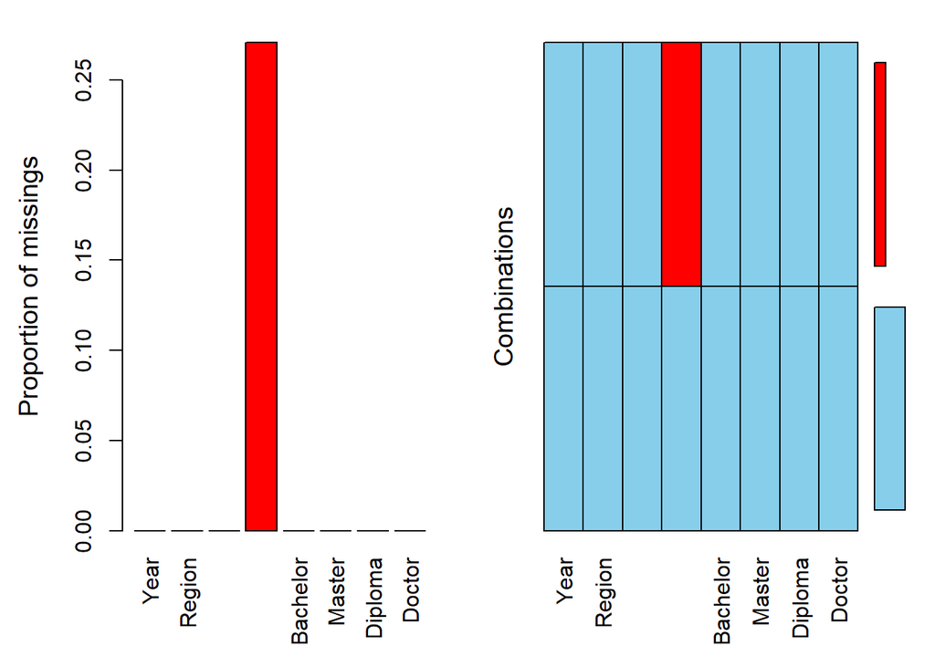

```r
####################################################### EDUCATION ACROSS REGIONS


education_filtered<-filter(education,Sex=='Total')
education_filtered$Sex<-NULL
education_filtered$Total<-NULL
education_filtered$`Specialised and engineering school certific. (GDR)`<-as.numeric(education_filtered$`Specialised and engineering school certific. (GDR)`)
education_filtered$Year<-as.numeric(education_filtered$Year)
education_filtered<-rename(education_filtered,'Trade_and_technical_school_certificate'='Trade and technical school certificate')
education_filtered<-rename(education_filtered,'Specialised_and_engineering_school_certificate_GDR'='Specialised and engineering school certific. (GDR)')
education_filtered<-rename(education_filtered,"Doctor"="Doctor's degree")

library(VIM)
aggr(education_filtered)
```

```r
library(mice)
library(foreign)
imp<-mice(education_filtered,method='pmm',maxit=10,m=1)
?complete()
```

```
## запускаю httpd сервер помощи... готово
```

```r
education_filtered<-complete(imp,action='long',include=FALSE)

education_filtered$.imp<-NULL
education_filtered$.id<-NULL

education_filtered<-education_filtered%>%
  mutate(Total=Trade_and_technical_school_certificate+Specialised_and_engineering_school_certificate_GDR+Bachelor+Master+Diploma+Doctor)
education_filtered<-education_filtered%>%
  select(Year,Region,Total)

education_clean_full<-education_filtered%>%
  pivot_wider(names_from='Year',
              values_from='Total')
```

## PRE-PROCESS R&D DATA

```r
######################################################### RESEARCH AND DEVELOPMENT ACROSS REGIONS



RD_filtered<-na.omit(RD)
RD_filtered<-filter(RD_filtered,Unit=='EUR mn')
RD_filtered$Unit<-NULL
RD_filtered$Type<-NULL

RD_filtered<-pivot_longer(RD_filtered, cols=('Baden-Württemberg':'Thüringen'),
                          values_to='Value',
                          names_to='Region')
RD_filtered<-pivot_wider(RD_filtered,
                         names_from='Sector',
                         values_from='Value')

RD_filtered$Gov<-RD_filtered$`Government, private non-profit institutions`
RD_filtered$`Government, private non-profit institutions`<-NULL
RD_total<-select(RD_filtered,Year,Region,Total)

RD_clean<-pivot_wider(RD_total,
                         names_from='Year',
                         values_from='Total')
```

## MERGING EVERYTHING

```r
############################################################# MERGING AND PRE-PROCESS FULL DATA

full_data<-merge(gdp_clean_full,RD_clean,by='Region')
full_data<-merge(full_data,education_clean_full,by='Region')

full_data<-full_data%>%
  rename('2017_gdpmln'='2017.x')%>%
  rename('2018_gdpmln'='2018.x')%>%
  rename('2019_gdpmln'='2019.x')%>%
  rename('2017_rdmln'='2017.y')%>%
  rename('2018_rdmln'='2018.y')%>%
  rename('2019_rdmln'='2019.y')%>%
  rename('2017_eduthous'='2017')%>%
  rename('2018_eduthous'='2018')%>%
  rename('2019_eduthous'='2019')

full_data<-pivot_longer(full_data,cols=starts_with('20'),
                        names_to='Year',
                        values_to='Value')
full_data<-separate(full_data,col='Year',into=c('Year','Type'),sep='_')
full_data<-pivot_wider(full_data,
                       names_from='Type',
                       values_from='Value')

############################################################# UPLOADING MAP AND MERGING WITH FULL DATA

library(sf)

germany<-st_read('gadm41_DEU_2.shp')
germany<-germany<-rename(germany,Region=NAME_1)

map_data<-merge(germany,full_data,by='Region')
map_data<-select(map_data,Region,Year,gdpmln,rdmln,eduthous,geometry)

map_data<-st_as_sf(map_data)
```

```r
colnames(map_data)
```

```
## [1] "Region"   "Year"     "gdpmln"   "rdmln"    "eduthous" "geometry"
```

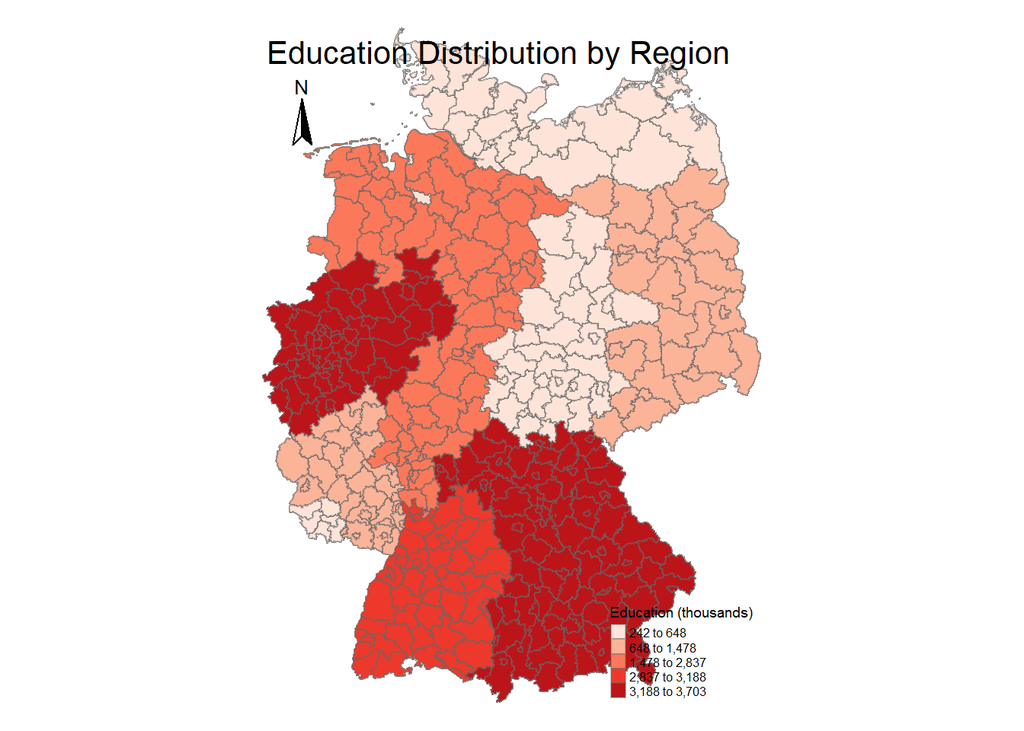

```r
#plot the distribution of variables (Education)
tm_shape(map_data) +
  tm_fill("eduthous", palette = "Reds",
          style = "quantile", title = "Education (thousands)") +
  tm_borders(alpha = 0.4) +
  tm_compass(position = c("left", "top")) +
  tm_layout(
    title = "Education Distribution by Region",
    legend.text.size = 0.5,
    legend.title.size = 0.7,
    legend.position = c("right", "bottom"),
    legend.width = 1.5,
    frame = FALSE
  )
```

The second bubble plot illustrates the R&D expenditure, with larger and darker blue bubbles **higher R&D investments**, while the opposite for the lower investments as regions with lack of infrastructure and funding..

```
## Legend labels were too wide. The labels have been resized to 1.04, 0.91, 0.84, 0.78, 0.78. Increase legend.width (argument of tm_layout) to make the legend wider and therefore the labels larger.
```

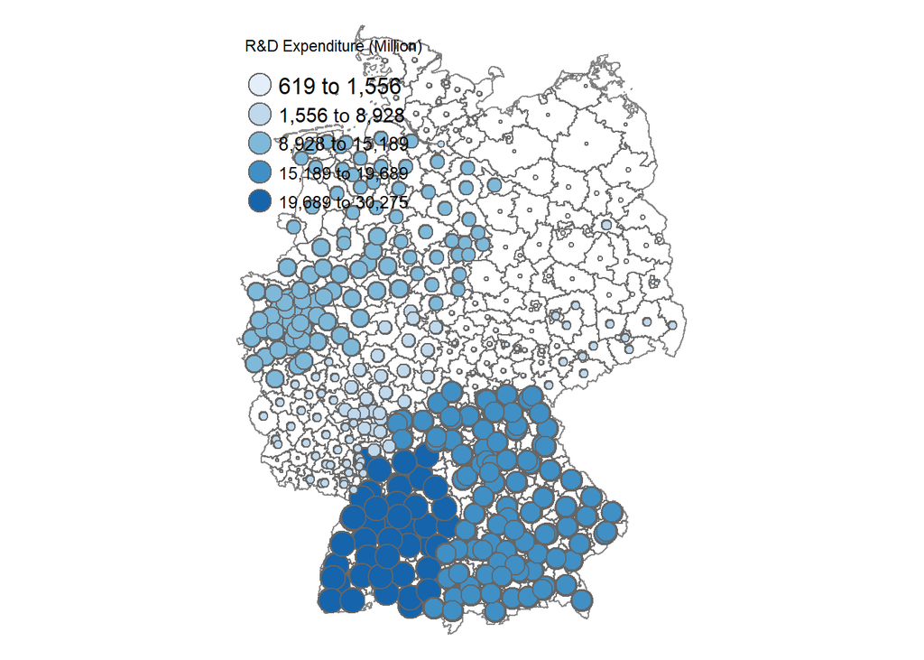

```r
#plot the distribution for another variable (R&D)
tm_shape(map_data) +
  tm_borders(alpha = 0.4) +
  tm_bubbles(size = "rdmln", col = "rdmln",
             palette = "Blues", style = "quantile",
             legend.size.show = FALSE, title.col = "R&D Expenditure (Million)") +
  tm_layout(
    legend.text.size = 1.1,
    legend.title.size = 1.4,
    frame = FALSE
  )
```

Third plot is **2 in 1**, which represents two variables in one plot, where we can conclude that regions with higher education levels often align with regions that invest more in R&D. This suggests that a more educated population contributes to innovation and research activities and educational infrastructure supports industries that prioritize R&D investments.

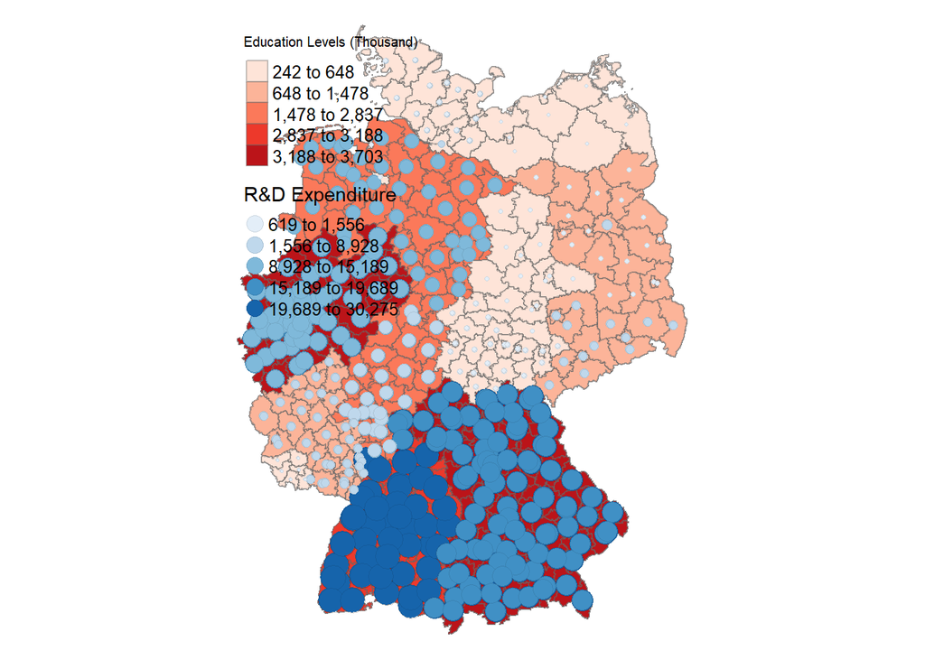

```r
#2 in 1
tm_shape(map_data) +
  tm_fill("eduthous", palette = "Reds",
          style = "quantile", title = "Education Levels (Thousand)") +
  tm_borders(alpha = 0.4) +
  tm_shape(map_data) +
  tm_bubbles(size = "rdmln", col = "rdmln",
             palette = "Blues", style = "quantile",
             legend.size.show = FALSE, title.col = "R&D Expenditure",
             border.col = "black", border.lwd = 0.1, border.alpha = 0.1) +
  tm_layout(
    legend.text.size = 0.8,
    legend.title.size = 1.1,
    frame = FALSE
  )
```

## AUTO-SPATIAL ANALYSIS: NEIGHBOURS

The analysis explores whether regions with similar education levels, or R&D expenditures are geographically clustered. To achieve this, spatial relationships between regions are defined using two criteria: the “queen” criterion, where regions sharing any boundary point are neighbors, and the “rook” criterion, where only regions sharing an edge qualify as neighbors. The “poly2nb” function is used to establish these neighbor relationships, while the “nb2listw” function converts them into a spatial weight matrix. This matrix quantifies the influence of neighboring regions on one another, forming the foundation for statistical tests like Moran’s I, which measures global spatial autocorrelation.

```r
#let's find neighbours

library(tmap)
library(sf)
library(spdep)
```

```r
neighbours <- poly2nb(map_data)
neighbours
```

```
## Neighbour list object:
## Number of regions: 1209
## Number of nonzero links: 21354
## Percentage nonzero weights: 1.460921
## Average number of links: 17.66253
```

**Output:**

Percentage nonzero weights: 1.460921

Average number of links: 17.66253 #each region has around 17.6 neighbors

Weights style: W (the weights matrix is row-standardized. Each row sums to 1, ensuring that the influence of neighbors is proportionally distributed)

Weights constants summary:

n nn S0 S1 S2

W 1209 1461681 1209 157.2312 5004.012  
Row-standardized weights show that the spatial relationships are comparable across regions regardless of the number of neighbors. The summary statistics (S0, S1, S2) reflect the structure and scaling of the spatial relationships.

## AUTO-SPATIAL ANALYSIS: SPATIAL AUTOCORRELATION

This section applies Moran’s I statistics to examine spatial autocorrelation in R&D expenditures across regions. Global Moran’s I, computed using **moran.test**, quantifies whether similar values cluster spatially. A significant result suggests that high or low R&D values are not randomly distributed but exhibit clustering patterns.

The Moran plot visualizes this relationship by comparing each region’s R&D values against the spatially lagged values of its neighbors, offering insights into positive or negative spatial autocorrelation.

Local Moran’s I, calculated with **localmoran**, identifies specific regions contributing to the observed global pattern. Regions with significant local Moran statistics are potential hotspots (clusters of high values) or cold spots (clusters of low values).

This analysis helps pinpoint spatial patterns, aiding in understanding regional disparities and informing policy decisions for equitable resource distribution and development strategies.

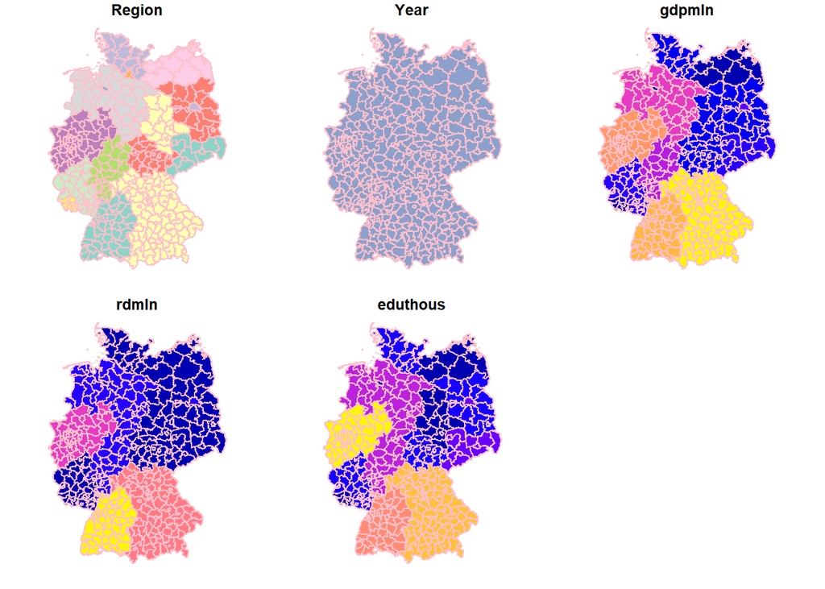

```r
plot(map_data, border = 'pink')
```

```r
#spatial autocorrelation

neighbours2 <- poly2nb(map_data, queen = FALSE)
neighbours2
```

```
## Neighbour list object:
## Number of regions: 1209
## Number of nonzero links: 21354
## Percentage nonzero weights: 1.460921
## Average number of links: 17.66253
```

```r
listw <- nb2listw(neighbours2)
listw
```

```
## Characteristics of weights list object:
## Neighbour list object:
## Number of regions: 1209
## Number of nonzero links: 21354
## Percentage nonzero weights: 1.460921
## Average number of links: 17.66253
##
## Weights style: W
## Weights constants summary:
##      n      nn   S0       S1       S2
## W 1209 1461681 1209 157.2312 5004.012
```

**Moran I test under randomisation**

data: map_data$rdmln

weights: listw

Moran I statistic standard deviate = 87.891, p-value < 2.2e-16

alternative hypothesis: greater

**Moran I statistic Expectation Variance**

**0.9049065164 -0.0008278146 0.0001061966**

A value of 0.9 indicates a very high positive spatial autocorrelation. Regions with similar R&D expenditure levels tend to cluster geographically.

**Standard deviate:** 87.891 is the z-score for Moran’s I. A very high z-score indicates strong deviation from randomness, further confirming significant spatial clustering

#### The expected Moran’s I value under the null hypothesis (random distribution). This is close to zero, which aligns with no spatial autocorrelation.

#### The variance of Moran’s I under the null hypothesis, used to compute the test statistic.

**Null Hypothesis:** There is no spatial autocorrelation (R&D values are randomly distributed).

**Alternative Hypothesis:** Spatial autocorrelation exists (R&D values are spatially clustered). **p-value < 2.2e-16:** reject the null hypothesis.

**Conclusion: There is significant positive spatial autocorrelation in R&D expenditure.**

## AUTO-SPATIAL ANALYSIS: MORAN TEST

This section integrates the calculated local Moran’s I statistics with the polygon shapefile of regional boundaries to visualize spatial autocorrelation patterns geographically. The results from localmoran are merged into the map_dataobject using cbind, ensuring that each region’s polygon is enriched with its respective local Moran statistic.

The visualization, created using the tm_shape and tm_fill functions, displays regions colored based on their local Moran’s I values. A quantile classification method ensures an even distribution of values across categories, making patterns easy to interpret. Regions with higher or lower values are highlighted, reflecting clusters of similar R&D expenditure levels.

The map provides an intuitive spatial representation of local clustering, with the borders overlaid for clarity. The visualization facilitates identifying specific regions contributing to global spatial patterns, aiding in spatial decision-making and policy interventions.

```r
# global spatial autocorrelation

moran.test(map_data$rdmln, listw)
```

```
##
##  Moran I test under randomisation
##
## data:  map_data$rdmln
## weights: listw
##
## Moran I statistic standard deviate = 87.891, p-value < 2.2e-16
## alternative hypothesis: greater
## sample estimates:
## Moran I statistic       Expectation          Variance
##      0.9049065164     -0.0008278146      0.0001061966
```

## AUTO-SPATIAL ANALYSIS: MORAN PLOT

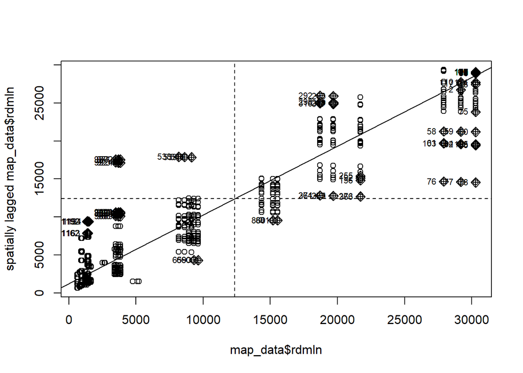

```r
#moran plot

moran <- moran.plot(map_data$rdmln, listw = nb2listw(neighbours2, style = "W"))
```

## AUTO-SPATIAL ANALYSIS: LOCAL MORAN OUTPUT & MORAN MAP

```
## Variable(s) "Ii" contains positive and negative values, so midpoint is set to 0. Set midpoint = NA to show the full spectrum of the color palette.
```

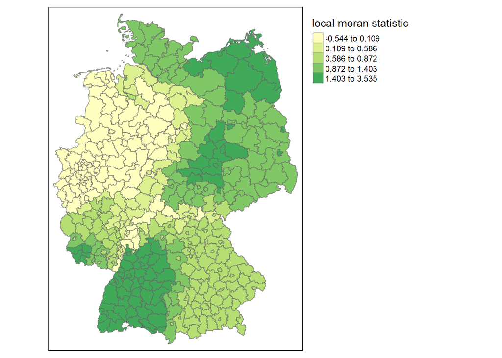

```r
#local moran output

local <- localmoran(x = map_data$rdmln, listw = nb2listw(neighbours2, style = "W"))

# binds results to our polygon shapefile
moran.map <- cbind(map_data, local)
# maps the results
tm_shape(moran.map) + tm_fill(col = "Ii", style = "quantile", title = "local moran statistic") +
  tm_borders(alpha = 0.4) +
  tm_layout(legend.outside = TRUE)
```

**References:**

[1] Kiese, M. (2019). Regional cluster policies in Germany: challenges, impacts and evaluation practices. The Journal of Technology Transfer, 44(6), 1698-1719.

[2] Haak, R., Gautam, V., Walsh, S. T., & White, C. G. (2014). The role of economic cluster perspectives in regional economic development. World Technopolis Review, 3(1), 17-29.

[3] Szendi, D. CONVERGENCE AND SPATIAL AUTOCORRELATION IN GERMANY–SPECIFIC GDP INEQUALITIES 30 YEARS AFTER THE FALL OF THE BERLIN WALL.

[4] Zierahn, U. (2012). The importance of spatial autocorrelation for regional employment growth in Germany. Jahrbuch für Regionalwissenschaft, 32, 19-43.

## DATASETS:

All datasets and information were taken from the official Germany statistics website: https://www-genesis.destatis.de/datenbank/online/statistics And at official website of the European Union(Eurostat): https://ec.europa.eu/eurostat